# Livestock project -Secondary analysis (100 years)-

Shun Hasegawa

11/05/2017

## Introduction

Here, I show the preliminary analysis of rainfall patterns for the livestock project. Firstly, I picked up 13 focal sites which had average annul precipitation = 800 mm ± 20% from SA, VIC and NSW as below.

[figure not shown]

Location of analysed sites.

Avg. annual precipitation of the focal sites over the past 100 years with standard deviation (std.) and coefficient of variance (cov.). The 1st to 5th driest years are also shown with rainfall and %reudction relative to the long-term averages.

| Site.name | unit | avg. | std. | cov. | driest_yr1 | driest_yr2 | driest_yr3 | driest_yr4 | driest_yr5 |
| --- | --- | --- | --- | --- | --- | --- | --- | --- | --- |
| ARMIDALE | mm yr-1 | 771 | 172 | 0.22 | 1982(460mm,-40%) | 1997(468mm,-39%) | 1965(479mm,-38%) | 1923(498mm,-35%) | 1918(504mm,-35%) |
| BIRREGURRA | mm yr-1 | 656 | 118 | 0.18 | 1967(335mm,-49%) | 2006(390mm,-40%) | 1982(416mm,-37%) | 1940(462mm,-30%) | 1976(472mm,-28%) |
| BRINGELLY | mm yr-1 | 726 | 274 | 0.38 | 1993(0mm,-100%) | 1994(0mm,-100%) | 1999(0mm,-100%) | 2009(0mm,-100%) | 1944(326mm,-55%) |
| CAMDEN | mm yr-1 | 755 | 237 | 0.31 | 1944(336mm,-56%) | 1940(410mm,-46%) | 1965(416mm,-45%) | 1941(423mm,-44%) | 1968(426mm,-44%) |
| COBDEN | mm yr-1 | 846 | 136 | 0.16 | 2006(497mm,-41%) | 1967(509mm,-40%) | 2015(590mm,-30%) | 1982(604mm,-29%) | 1925(616mm,-27%) |
| COLAC | mm yr-1 | 696 | 172 | 0.25 | 1969(44mm,-94%) | 1983(316mm,-55%) | 1996(359mm,-48%) | 2006(412mm,-41%) | 1987(427mm,-39%) |
| GOULBURN | mm yr-1 | 662 | 227 | 0.34 | 1918(0mm,-100%) | 2011(0mm,-100%) | 1920(96mm,-86%) | 1944(240mm,-64%) | 1919(270mm,-59%) |
| KOLORA | mm yr-1 | 641 | 138 | 0.22 | 1967(386mm,-40%) | 1938(391mm,-39%) | 2015(405mm,-37%) | 1925(410mm,-36%) | 1920(440mm,-31%) |
| MOE | mm yr-1 | 945 | 182 | 0.19 | 1996(382mm,-60%) | 1972(572mm,-40%) | 1967(582mm,-38%) | 2006(616mm,-35%) | 1981(637mm,-33%) |
| PICTON | mm yr-1 | 735 | 329 | 0.45 | 1988(0mm,-100%) | 1989(0mm,-100%) | 1991(0mm,-100%) | 1992(0mm,-100%) | 1994(0mm,-100%) |
| TANGAMBALANGA | mm yr-1 | 697 | 278 | 0.40 | 1935(0mm,-100%) | 1936(0mm,-100%) | 1972(0mm,-100%) | 1973(0mm,-100%) | 2000(0mm,-100%) |
| TERANG | mm yr-1 | 781 | 150 | 0.19 | 1992(158mm,-80%) | 2006(460mm,-41%) | 1982(508mm,-35%) | 1967(530mm,-32%) | 2014(584mm,-25%) |
| VICTOR | mm yr-1 | 702 | 134 | 0.19 | 1967(405mm,-42%) | 1959(415mm,-41%) | 2006(448mm,-36%) | 1982(452mm,-36%) | 1957(483mm,-31%) |

Avg. spring precipitation of the focal sites over the past 100 years with standard deviation (std.) and coefficient of variance (cov.). The 1st to 5th driest years are also shown with rainfall and %reudction relative to the long-term averages.

| Site.name | unit | avg. | std. | cov. | driest_yr1 | driest_yr2 | driest_yr3 | driest_yr4 | driest_yr5 |
| --- | --- | --- | --- | --- | --- | --- | --- | --- | --- |
| ARMIDALE | mm yr-1 | 238 | 77 | 0.32 | 1951(101mm,-57%) | 1918(111mm,-53%) | 1926(114mm,-52%) | 1935(124mm,-48%) | 1944(125mm,-47%) |
| BIRREGURRA | mm yr-1 | 161 | 56 | 0.34 | 1943(51mm,-69%) | 2006(57mm,-65%) | 1919(58mm,-64%) | 1963(65mm,-60%) | 1972(65mm,-60%) |
| BRINGELLY | mm yr-1 | 185 | 103 | 0.56 | 1993(0mm,-100%) | 1994(0mm,-100%) | 1999(0mm,-100%) | 2009(0mm,-100%) | 1951(28mm,-85%) |
| CAMDEN | mm yr-1 | 196 | 96 | 0.49 | 1951(26mm,-87%) | 1944(32mm,-84%) | 1918(44mm,-78%) | 1928(46mm,-77%) | 1982(56mm,-71%) |
| COBDEN | mm yr-1 | 201 | 62 | 0.31 | 2015(74mm,-63%) | 2006(75mm,-63%) | 1963(88mm,-56%) | 1938(96mm,-52%) | 2014(99mm,-51%) |
| COLAC | mm yr-1 | 169 | 66 | 0.39 | 1968(0mm,-100%) | 1995(0mm,-100%) | 1969(44mm,-74%) | 1963(54mm,-68%) | 2006(62mm,-64%) |
| GOULBURN | mm yr-1 | 174 | 87 | 0.50 | 1918(0mm,-100%) | 1919(0mm,-100%) | 1920(0mm,-100%) | 2011(0mm,-100%) | 1977(3mm,-98%) |
| KOLORA | mm yr-1 | 160 | 59 | 0.37 | 1931(45mm,-72%) | 1938(56mm,-65%) | 1925(58mm,-64%) | 2014(58mm,-64%) | 1963(59mm,-63%) |
| MOE | mm yr-1 | 246 | 79 | 0.32 | 1996(32mm,-87%) | 2015(78mm,-68%) | 2006(85mm,-66%) | 1977(105mm,-57%) | 1943(107mm,-56%) |
| PICTON | mm yr-1 | 194 | 120 | 0.62 | 1987(0mm,-100%) | 1988(0mm,-100%) | 1989(0mm,-100%) | 1990(0mm,-100%) | 1991(0mm,-100%) |
| TANGAMBALANGA | mm yr-1 | 165 | 97 | 0.59 | 1934(0mm,-100%) | 1935(0mm,-100%) | 1936(0mm,-100%) | 1972(0mm,-100%) | 1973(0mm,-100%) |
| TERANG | mm yr-1 | 185 | 60 | 0.32 | 1989(45mm,-76%) | 1963(60mm,-67%) | 2006(75mm,-59%) | 2015(84mm,-55%) | 1919(93mm,-50%) |
| VICTOR | mm yr-1 | 122 | 46 | 0.37 | 2006(30mm,-76%) | 2015(32mm,-74%) | 1967(45mm,-63%) | 1982(51mm,-58%) | 1938(55mm,-55%) |

Avg. summer precipitation of the focal sites over the past 100 years with standard deviation (std.) and coefficient of variance (cov.). The 1st to 5th driest years are also shown with rainfall and %reudction relative to the long-term averages.

| Site.name | unit | avg. | std. | cov. | driest_yr1 | driest_yr2 | driest_yr3 | driest_yr4 | driest_yr5 |
| --- | --- | --- | --- | --- | --- | --- | --- | --- | --- |
| ARMIDALE | mm yr-1 | 257 | 86 | 0.33 | 1965(78mm,-70%) | 1986(88mm,-66%) | 1981(103mm,-60%) | 1923(115mm,-55%) | 1943(138mm,-46%) |
| BIRREGURRA | mm yr-1 | 104 | 50 | 0.48 | 2013(20mm,-81%) | 1953(34mm,-67%) | 1961(35mm,-66%) | 1923(36mm,-65%) | 1986(39mm,-62%) |
| BRINGELLY | mm yr-1 | 244 | 134 | 0.55 | 1993(0mm,-100%) | 1994(0mm,-100%) | 1999(0mm,-100%) | 2009(0mm,-100%) | 1965(25mm,-90%) |
| CAMDEN | mm yr-1 | 260 | 136 | 0.52 | 1940(20mm,-92%) | 1965(25mm,-90%) | 1923(74mm,-72%) | 1944(80mm,-69%) | 1979(106mm,-59%) |
| COBDEN | mm yr-1 | 130 | 61 | 0.47 | 1936(33mm,-75%) | 1953(44mm,-66%) | 1926(52mm,-60%) | 1961(56mm,-57%) | 2009(58mm,-55%) |
| COLAC | mm yr-1 | 110 | 60 | 0.55 | 1969(0mm,-100%) | 1996(0mm,-100%) | 2013(25mm,-77%) | 1953(31mm,-72%) | 1926(34mm,-69%) |
| GOULBURN | mm yr-1 | 159 | 96 | 0.60 | 1918(0mm,-100%) | 1921(0mm,-100%) | 1959(0mm,-100%) | 2011(0mm,-100%) | 1965(4mm,-98%) |
| KOLORA | mm yr-1 | 106 | 61 | 0.58 | 2013(19mm,-82%) | 1926(25mm,-77%) | 1953(30mm,-72%) | 1965(31mm,-71%) | 1936(32mm,-70%) |
| MOE | mm yr-1 | 173 | 79 | 0.46 | 1981(0mm,-100%) | 2009(12mm,-93%) | 1968(47mm,-73%) | 1965(72mm,-58%) | 1972(82mm,-52%) |
| PICTON | mm yr-1 | 247 | 164 | 0.67 | 1988(0mm,-100%) | 1989(0mm,-100%) | 1990(0mm,-100%) | 1991(0mm,-100%) | 1992(0mm,-100%) |
| TANGAMBALANGA | mm yr-1 | 126 | 94 | 0.75 | 1935(0mm,-100%) | 1936(0mm,-100%) | 1944(0mm,-100%) | 1972(0mm,-100%) | 1973(0mm,-100%) |
| TERANG | mm yr-1 | 124 | 77 | 0.62 | 1990(0mm,-100%) | 1993(0mm,-100%) | 1936(36mm,-71%) | 2013(43mm,-66%) | 1953(44mm,-65%) |
| VICTOR | mm yr-1 | 79 | 51 | 0.64 | 1980(12mm,-85%) | 1923(13mm,-84%) | 1965(17mm,-79%) | 1986(18mm,-78%) | 1957(18mm,-77%) |

Avg. autumn precipitation of the focal sites over the past 100 years with standard deviation (std.) and coefficient of variance (cov.). The 1st to 5th driest years are also shown with rainfall and %reudction relative to the long-term averages.

| Site.name | unit | avg. | std. | cov. | driest_yr1 | driest_yr2 | driest_yr3 | driest_yr4 | driest_yr5 |
| --- | --- | --- | --- | --- | --- | --- | --- | --- | --- |
| ARMIDALE | mm yr-1 | 135 | 68 | 0.51 | 1982(39mm,-71%) | 1917(42mm,-69%) | 1994(48mm,-65%) | 1935(49mm,-64%) | 1971(49mm,-64%) |
| BIRREGURRA | mm yr-1 | 173 | 51 | 0.29 | 1967(58mm,-66%) | 1959(75mm,-57%) | 1984(82mm,-53%) | 1937(95mm,-45%) | 1993(99mm,-43%) |
| BRINGELLY | mm yr-1 | 184 | 123 | 0.67 | 1993(0mm,-100%) | 1994(0mm,-100%) | 1999(0mm,-100%) | 2009(0mm,-100%) | 1971(7mm,-96%) |
| CAMDEN | mm yr-1 | 185 | 118 | 0.64 | 1954(28mm,-85%) | 1982(30mm,-84%) | 1993(35mm,-81%) | 1971(41mm,-78%) | 1957(48mm,-74%) |
| COBDEN | mm yr-1 | 229 | 67 | 0.29 | 1967(58mm,-75%) | 1984(98mm,-57%) | 1959(128mm,-44%) | 1950(137mm,-40%) | 2013(142mm,-38%) |
| COLAC | mm yr-1 | 188 | 67 | 0.36 | 1969(0mm,-100%) | 1996(0mm,-100%) | 1967(67mm,-64%) | 1983(73mm,-61%) | 1999(90mm,-52%) |
| GOULBURN | mm yr-1 | 158 | 87 | 0.55 | 1918(0mm,-100%) | 1920(0mm,-100%) | 1959(0mm,-100%) | 2011(0mm,-100%) | 2004(39mm,-76%) |
| KOLORA | mm yr-1 | 170 | 55 | 0.32 | 1967(51mm,-70%) | 2015(54mm,-68%) | 2013(77mm,-55%) | 1930(82mm,-52%) | 1959(90mm,-47%) |
| MOE | mm yr-1 | 250 | 79 | 0.32 | 1996(0mm,-100%) | 2005(98mm,-61%) | 1959(125mm,-50%) | 1967(126mm,-50%) | 1972(137mm,-45%) |
| PICTON | mm yr-1 | 177 | 131 | 0.74 | 1988(0mm,-100%) | 1989(0mm,-100%) | 1991(0mm,-100%) | 1992(0mm,-100%) | 1994(0mm,-100%) |
| TANGAMBALANGA | mm yr-1 | 182 | 99 | 0.54 | 1931(0mm,-100%) | 1935(0mm,-100%) | 1936(0mm,-100%) | 1972(0mm,-100%) | 1973(0mm,-100%) |
| TERANG | mm yr-1 | 213 | 62 | 0.29 | 1992(0mm,-100%) | 1967(72mm,-66%) | 1984(92mm,-57%) | 1959(114mm,-47%) | 2008(123mm,-42%) |
| VICTOR | mm yr-1 | 229 | 66 | 0.29 | 1959(57mm,-75%) | 1967(61mm,-74%) | 1930(117mm,-49%) | 1993(118mm,-49%) | 1941(123mm,-46%) |

Avg. winter precipitation of the focal sites over the past 100 years with standard deviation (std.) and coefficient of variance (cov.). The 1st to 5th driest years are also shown with rainfall and %reudction relative to the long-term averages.

| Site.name | unit | avg. | std. | cov. | driest_yr1 | driest_yr2 | driest_yr3 | driest_yr4 | driest_yr5 |
| --- | --- | --- | --- | --- | --- | --- | --- | --- | --- |
| ARMIDALE | mm yr-1 | 147 | 68 | 0.46 | 1927(23mm,-85%) | 1941(32mm,-79%) | 1980(40mm,-73%) | 1919(42mm,-72%) | 1940(44mm,-70%) |
| BIRREGURRA | mm yr-1 | 218 | 58 | 0.27 | 1944(100mm,-54%) | 2006(104mm,-52%) | 1982(105mm,-52%) | 1949(108mm,-51%) | 1938(119mm,-45%) |
| BRINGELLY | mm yr-1 | 114 | 75 | 0.66 | 1993(0mm,-100%) | 1994(0mm,-100%) | 1999(0mm,-100%) | 2009(0mm,-100%) | 1980(20mm,-82%) |
| CAMDEN | mm yr-1 | 115 | 69 | 0.60 | 1946(17mm,-85%) | 1994(21mm,-82%) | 1980(21mm,-81%) | 1968(28mm,-76%) | 2002(28mm,-76%) |
| COBDEN | mm yr-1 | 286 | 70 | 0.24 | 1982(138mm,-52%) | 2006(147mm,-49%) | 1949(158mm,-45%) | 1938(168mm,-41%) | 1987(170mm,-40%) |
| COLAC | mm yr-1 | 229 | 82 | 0.36 | 1969(0mm,-100%) | 1983(0mm,-100%) | 1987(0mm,-100%) | 1995(0mm,-100%) | 1968(72mm,-69%) |
| GOULBURN | mm yr-1 | 172 | 74 | 0.43 | 1917(0mm,-100%) | 1918(0mm,-100%) | 1920(0mm,-100%) | 2011(0mm,-100%) | 1994(31mm,-82%) |
| KOLORA | mm yr-1 | 205 | 58 | 0.28 | 1938(86mm,-58%) | 1940(97mm,-53%) | 1928(98mm,-52%) | 1944(99mm,-52%) | 1949(106mm,-48%) |
| MOE | mm yr-1 | 277 | 69 | 0.25 | 2006(143mm,-48%) | 1944(144mm,-48%) | 1996(149mm,-46%) | 2011(153mm,-45%) | 1971(162mm,-41%) |
| PICTON | mm yr-1 | 117 | 85 | 0.73 | 1987(0mm,-100%) | 1988(0mm,-100%) | 1989(0mm,-100%) | 1990(0mm,-100%) | 1991(0mm,-100%) |
| TANGAMBALANGA | mm yr-1 | 225 | 106 | 0.47 | 1934(0mm,-100%) | 1935(0mm,-100%) | 1936(0mm,-100%) | 1972(0mm,-100%) | 1973(0mm,-100%) |
| TERANG | mm yr-1 | 259 | 68 | 0.26 | 1992(0mm,-100%) | 1982(130mm,-50%) | 1949(137mm,-47%) | 2006(137mm,-47%) | 1938(137mm,-47%) |
| VICTOR | mm yr-1 | 271 | 71 | 0.26 | 1982(104mm,-61%) | 2006(136mm,-50%) | 1949(140mm,-48%) | 1944(144mm,-47%) | 1994(145mm,-47%) |

Avg. May precipitation of the focal sites over the past 100 years with standard deviation (std.) and coefficient of variance (cov.). The 1st to 5th driest years are also shown with rainfall and %reudction relative to the long-term averages.

| Site.name | unit | avg. | std. | cov. | driest_yr1 | driest_yr2 | driest_yr3 | driest_yr4 | driest_yr5 |
| --- | --- | --- | --- | --- | --- | --- | --- | --- | --- |
| ARMIDALE | mm yr-1 | 43 | 37 | 0.86 | 1957(1mm,-98%) | 1923(3mm,-92%) | 1927(4mm,-90%) | 1918(7mm,-84%) | 1994(7mm,-83%) |
| BIRREGURRA | mm yr-1 | 61 | 31 | 0.51 | 1934(6mm,-90%) | 1996(8mm,-87%) | 1932(13mm,-78%) | 1959(18mm,-71%) | 1990(18mm,-70%) |
| BRINGELLY | mm yr-1 | 55 | 62 | 1.13 | 1918(0mm,-100%) | 1971(0mm,-100%) | 1993(0mm,-100%) | 1994(0mm,-100%) | 1999(0mm,-100%) |
| CAMDEN | mm yr-1 | 55 | 60 | 1.09 | 1957(1mm,-99%) | 2008(1mm,-98%) | 1954(2mm,-97%) | 1982(2mm,-97%) | 2005(2mm,-96%) |
| COBDEN | mm yr-1 | 82 | 40 | 0.49 | 1932(15mm,-82%) | 1996(17mm,-79%) | 1934(18mm,-78%) | 1967(22mm,-73%) | 1991(25mm,-70%) |
| COLAC | mm yr-1 | 65 | 36 | 0.55 | 1969(0mm,-100%) | 1983(0mm,-100%) | 1985(0mm,-100%) | 1996(0mm,-100%) | 1934(10mm,-85%) |
| GOULBURN | mm yr-1 | 51 | 45 | 0.88 | 1918(0mm,-100%) | 1920(0mm,-100%) | 1959(0mm,-100%) | 2011(0mm,-100%) | 1964(4mm,-93%) |
| KOLORA | mm yr-1 | 60 | 32 | 0.54 | 2013(0mm,-100%) | 2015(0mm,-100%) | 1934(5mm,-91%) | 1996(7mm,-88%) | 1932(12mm,-80%) |
| MOE | mm yr-1 | 88 | 48 | 0.54 | 1996(0mm,-100%) | 1934(6mm,-93%) | 1932(17mm,-81%) | 2001(24mm,-73%) | 1947(28mm,-68%) |
| PICTON | mm yr-1 | 52 | 64 | 1.25 | 1987(0mm,-100%) | 1988(0mm,-100%) | 1989(0mm,-100%) | 1990(0mm,-100%) | 1991(0mm,-100%) |
| TANGAMBALANGA | mm yr-1 | 64 | 51 | 0.80 | 1926(0mm,-100%) | 1931(0mm,-100%) | 1934(0mm,-100%) | 1935(0mm,-100%) | 1936(0mm,-100%) |
| TERANG | mm yr-1 | 74 | 35 | 0.47 | 1992(0mm,-100%) | 1996(10mm,-86%) | 1934(12mm,-84%) | 1932(16mm,-78%) | 1959(24mm,-67%) |
| VICTOR | mm yr-1 | 80 | 37 | 0.47 | 2005(14mm,-82%) | 1934(14mm,-82%) | 1930(16mm,-80%) | 1959(16mm,-80%) | 1954(17mm,-79%) |

Avg. Jun precipitation of the focal sites over the past 100 years with standard deviation (std.) and coefficient of variance (cov.). The 1st to 5th driest years are also shown with rainfall and %reudction relative to the long-term averages.

| Site.name | unit | avg. | std. | cov. | driest_yr1 | driest_yr2 | driest_yr3 | driest_yr4 | driest_yr5 |
| --- | --- | --- | --- | --- | --- | --- | --- | --- | --- |
| ARMIDALE | mm yr-1 | 49 | 42 | 0.86 | 1986(2mm,-96%) | 1953(4mm,-91%) | 1947(6mm,-87%) | 1968(7mm,-86%) | 1934(9mm,-82%) |
| BIRREGURRA | mm yr-1 | 63 | 28 | 0.45 | 1937(18mm,-71%) | 1967(19mm,-69%) | 2006(20mm,-68%) | 1969(21mm,-67%) | 1997(22mm,-65%) |
| BRINGELLY | mm yr-1 | 64 | 75 | 1.18 | 1953(0mm,-100%) | 1962(0mm,-100%) | 1993(0mm,-100%) | 1994(0mm,-100%) | 1999(0mm,-100%) |
| CAMDEN | mm yr-1 | 64 | 75 | 1.18 | 1953(0mm,-100%) | 1954(0mm,-100%) | 1971(1mm,-98%) | 2001(2mm,-97%) | 1932(2mm,-96%) |
| COBDEN | mm yr-1 | 82 | 36 | 0.45 | 1937(15mm,-81%) | 1967(17mm,-79%) | 1969(19mm,-77%) | 2006(27mm,-67%) | 1997(28mm,-66%) |
| COLAC | mm yr-1 | 68 | 34 | 0.49 | 1969(0mm,-100%) | 1983(0mm,-100%) | 1985(0mm,-100%) | 1987(0mm,-100%) | 1996(0mm,-100%) |
| GOULBURN | mm yr-1 | 58 | 45 | 0.78 | 1917(0mm,-100%) | 1918(0mm,-100%) | 1920(0mm,-100%) | 1955(0mm,-100%) | 1959(0mm,-100%) |
| KOLORA | mm yr-1 | 59 | 26 | 0.45 | 1917(0mm,-100%) | 1969(10mm,-83%) | 1937(13mm,-78%) | 1930(19mm,-68%) | 1967(21mm,-64%) |
| MOE | mm yr-1 | 89 | 43 | 0.48 | 1996(0mm,-100%) | 2006(17mm,-81%) | 1972(18mm,-80%) | 1974(22mm,-75%) | 2015(32mm,-64%) |
| PICTON | mm yr-1 | 62 | 80 | 1.28 | 1987(0mm,-100%) | 1988(0mm,-100%) | 1989(0mm,-100%) | 1990(0mm,-100%) | 1991(0mm,-100%) |
| TANGAMBALANGA | mm yr-1 | 75 | 50 | 0.67 | 1931(0mm,-100%) | 1934(0mm,-100%) | 1935(0mm,-100%) | 1936(0mm,-100%) | 1972(0mm,-100%) |
| TERANG | mm yr-1 | 76 | 32 | 0.42 | 1992(0mm,-100%) | 1969(22mm,-71%) | 1937(25mm,-68%) | 2006(25mm,-67%) | 1967(28mm,-63%) |
| VICTOR | mm yr-1 | 97 | 44 | 0.45 | 1944(24mm,-75%) | 1967(26mm,-73%) | 1959(31mm,-68%) | 2015(37mm,-62%) | 1934(39mm,-60%) |

Then, I assessed extreme dry events in each site for winter, spring and winter & spring (W_S). The extreme events were identified as years with seasonal precipitation falling into less than **5%** quantile of the overall distribution of seasonal precipitation over the past 100 years.

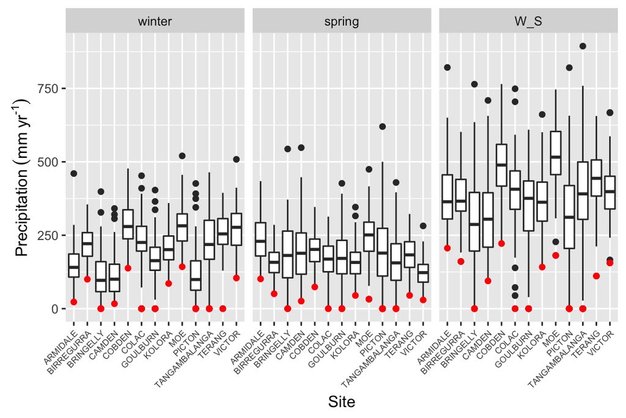

Seasonal rain distribution. Years that experienced extreme evets falls less than 5% quantile, shown with red.

## Characterisation of rainfall patters in extreme years

I characterized the rainfall pattern during extremely dry years using indices below.

- Avg. wet day rain (Rd)
- Max daily rain
- No. of dry days
- No. of wet days
- Max no. of contiguous duration of dry days
- Max no. of contiguous duration of wet days
- No. of days of each rain class
  - class0 (Rd < 1 mm)
  - class1 (1 < Rd $\leq$ 5 mm)
  - class2 (5 < Rd $\leq$ 20 mm)
  - class3 (Rd > 20 mm)

Below, I summarize multi-sites data and demonstrate the magnitude of extreme events given as $(x_e-x_a)/x_a$, where $x_e$ and $x_a$ are average values in extreme years and across all years, respectively.

| variable | mag.extrm winter | mag.extrm spring | mag.extrm w_s | no_site |
| --- | --- | --- | --- | --- |
| Avg. max wet day rain | -0.73 | -0.68 | -0.64 | 13 |
| Avg. max. no. contiguous duration of dry days | 2.90 | 2.33 | 3.64 | 13 |
| Avg. max. no. contiguous duration of wet days | -0.61 | -0.62 | -0.53 | 13 |
| Avg. no. class0 rain days | 0.31 | 0.23 | 0.26 | 13 |
| Avg. no. class1 rain days | -0.58 | -0.59 | -0.59 | 13 |
| Avg. no. class2 rain days | -0.73 | -0.84 | -0.75 | 13 |
| Avg. no. class3 rain days | -1.00 | -0.84 | -0.83 | 13 |
| Avg. no. dry days | 0.40 | 0.30 | 0.31 | 13 |
| Avg. no. wet days | -0.63 | -0.69 | -0.60 | 13 |
| Avg. seasonal rain | -0.77 | -0.83 | -0.75 | 13 |
| Avg. wet day rain | -0.41 | -0.36 | -0.26 | 7 |
| No. yr | -0.97 | -0.97 | -0.98 | 13 |
| Year | NA | NA | NA | 8 |

### Wet day rain

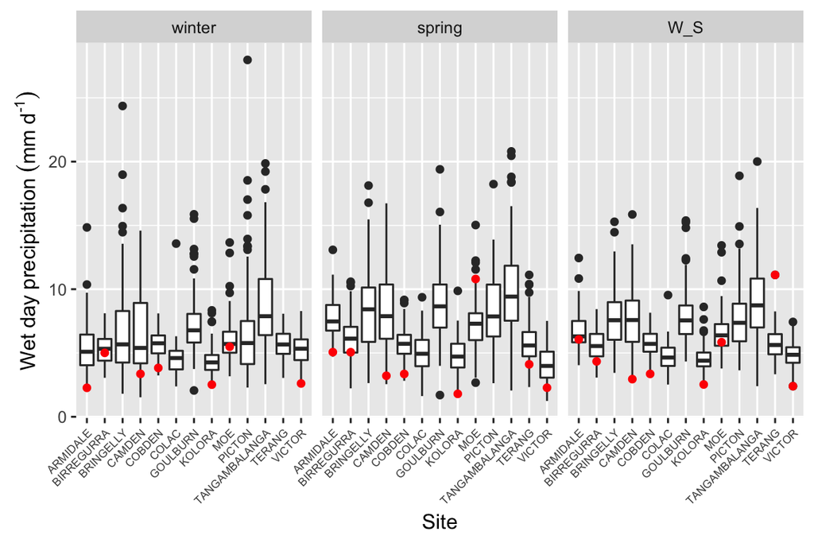

### Max daily rain

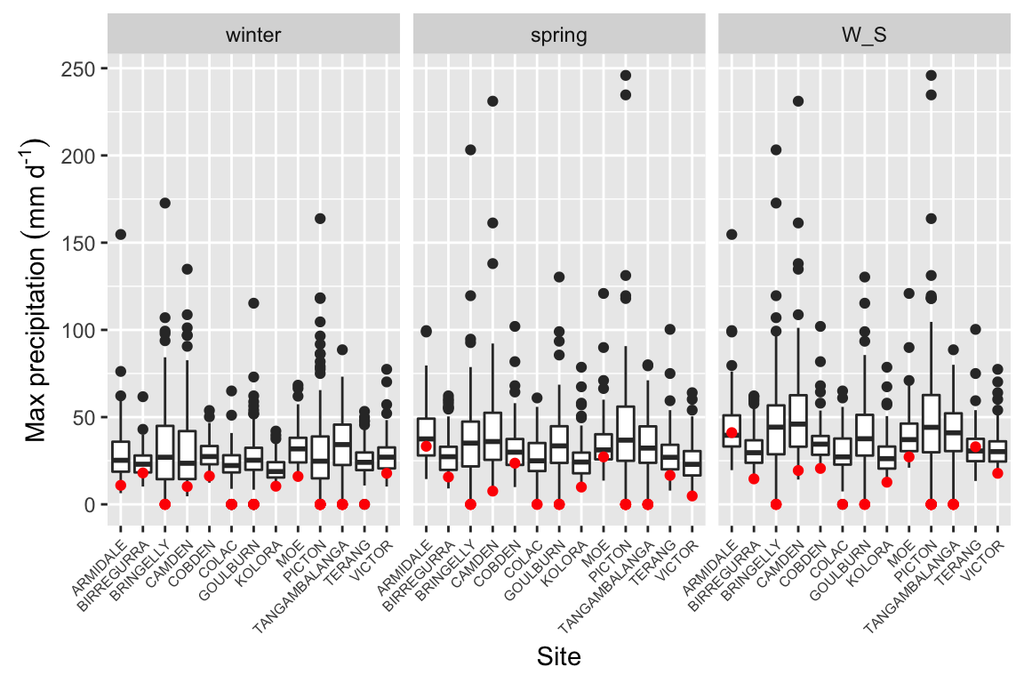

### No. of dry days

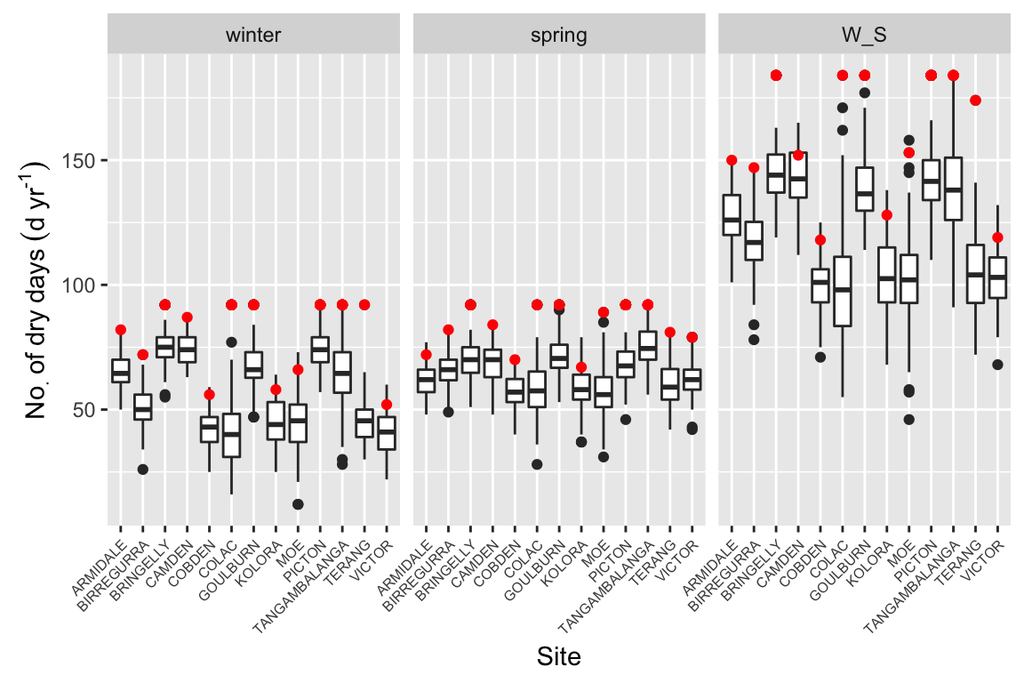

### No. of wet days

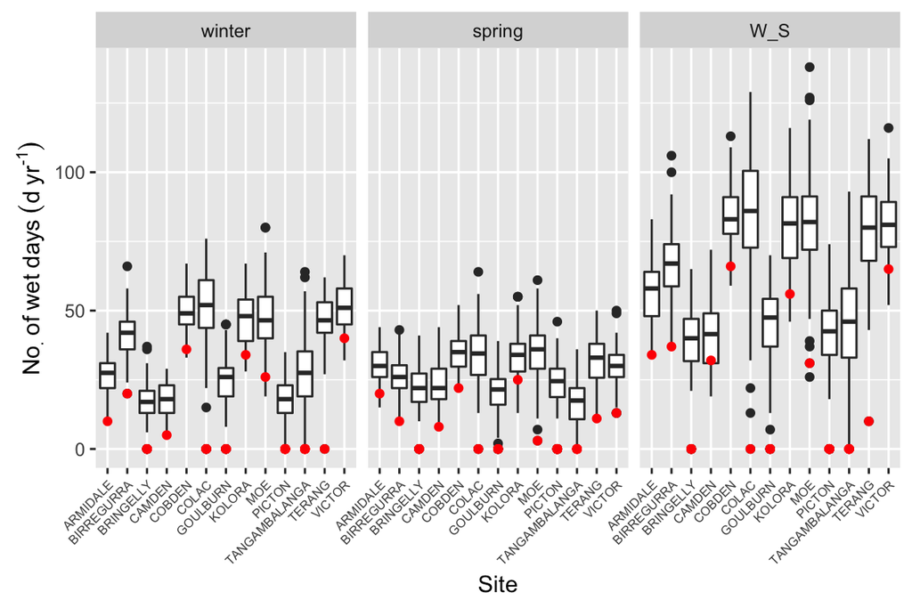

### Max no. of contiguous duration of dry days

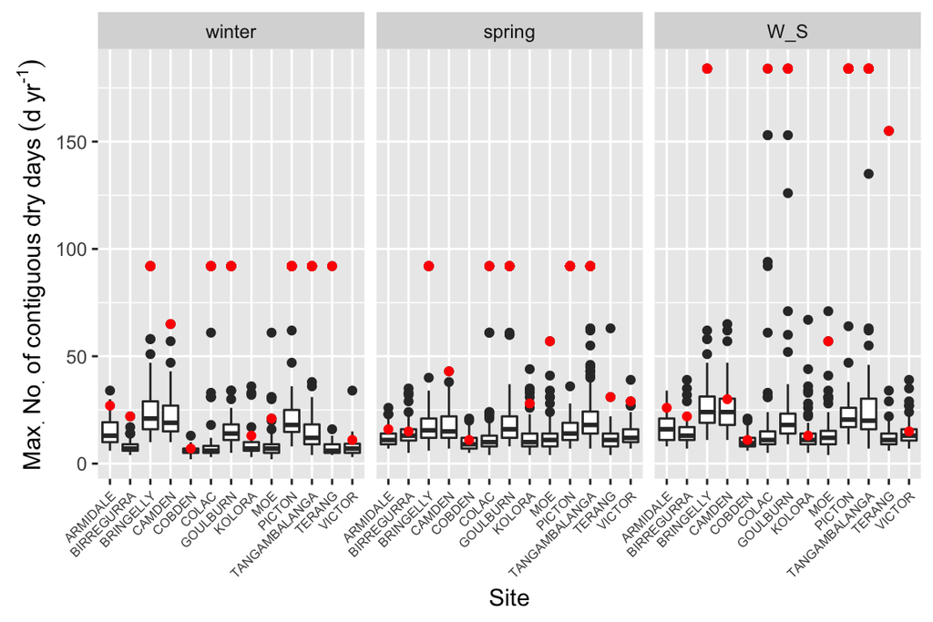

### Max no. of contiguous duration of wet days

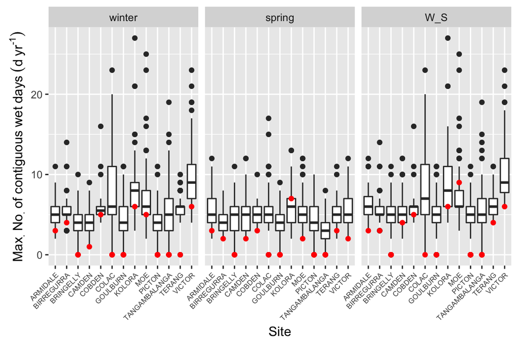

### No. of days of each rain class

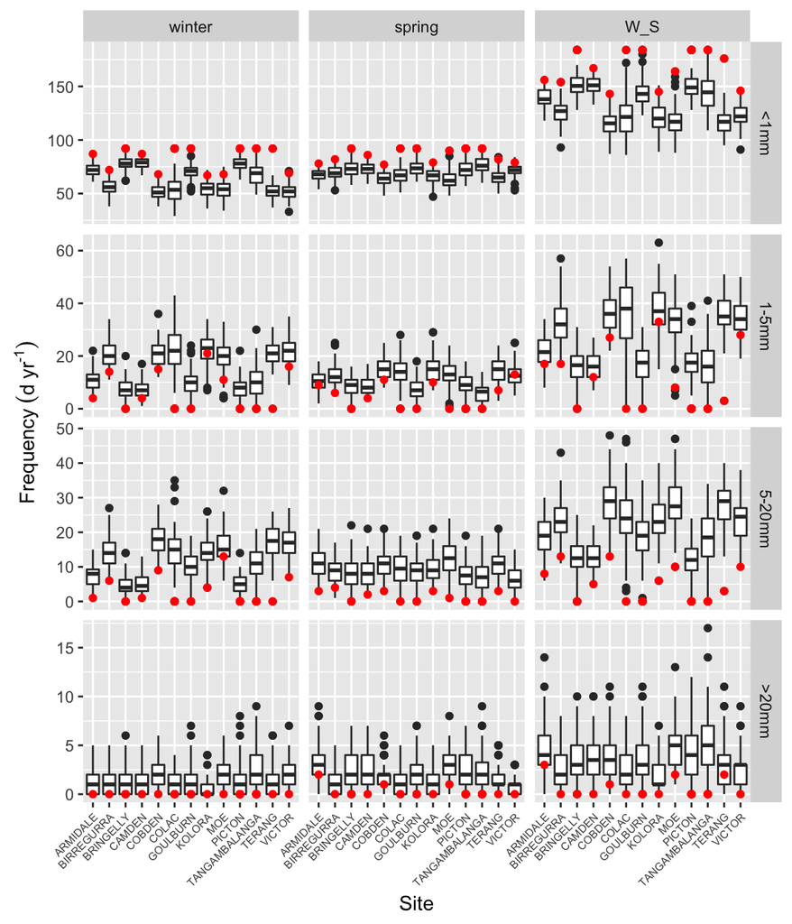

## Summay of focal sites

The indices above are summarised in a table for each site as below.

ARMIDALE

| variable | unit | winter extreme | winter overall | spring extreme | spring overall | W S extreme | W S overall |
| --- | --- | --- | --- | --- | --- | --- | --- |
| Avg. no. class0 rain days | d yr-1 | 87 | 72 | 78 | 67 | 156 | 140 |
| Avg. no. class1 rain days | d yr-1 | 4 | 11 | 9 | 10 | 17 | 21 |
| Avg. no. class2 rain days | d yr-1 | 1 | 7 | 3 | 11 | 8 | 19 |
| Avg. no. class3 rain days | d yr-1 | 0 | 1 | 2 | 3 | 3 | 4 |
| Avg. no. dry days | d yr-1 | 82 | 65.31 | 72 | 61.58 | 150 | 126.89 |
| Avg. max. no. contiguous duration of dry days | d yr-1 | 27 | 15 | 16 | 12 | 26 | 17 |
| Avg. no. wet days | d yr-1 | 10 | 26.69 | 20 | 30.43 | 34 | 57.11 |
| Avg. max. no. contiguous duration of wet days | d yr-1 | 3 | 5 | 3 | 6 | 3 | 6 |
| Avg. max wet day rain | mm d-1 | 10.9 | 29.53 | 33.3 | 39.66 | 41.1 | 44.01 |
| Avg. wet day rain | mm d-1 | 2.27 | 5.44 | 5.06 | 7.74 | 6.06 | 6.7 |
| St. dev. wet day rain | mm d-1 | - | 2.09 | - | 1.65 | - | 1.41 |
| Avg. seasonal rain | mm yr-1 | 22.7 | 146.84 | 101.3 | 237.53 | 206.1 | 384.37 |
| No. yr | yr | 1 | 80 | 1 | 80 | 1 | 80 |
| Year | yr | 1927 | 1917-1996 | 1951 | 1917-1996 | 1941 | 1917-1996 |

BIRREGURRA

| variable | unit | winter extreme | winter overall | spring extreme | spring overall | W S extreme | W S overall |
| --- | --- | --- | --- | --- | --- | --- | --- |
| Avg. no. class0 rain days | d yr-1 | 72 | 56 | 82 | 69 | 154 | 125 |
| Avg. no. class1 rain days | d yr-1 | 14 | 20 | 6 | 12 | 17 | 33 |
| Avg. no. class2 rain days | d yr-1 | 6 | 14 | 4 | 9 | 13 | 23 |
| Avg. no. class3 rain days | d yr-1 | 0 | 1 | 0 | 1 | 0 | 3 |
| Avg. no. dry days | d yr-1 | 72 | 50.97 | 82 | 65.56 | 147 | 116.53 |
| Avg. max. no. contiguous duration of dry days | d yr-1 | 22 | 8 | 15 | 14 | 22 | 15 |
| Avg. no. wet days | d yr-1 | 20 | 41.03 | 10 | 26.44 | 37 | 67.47 |
| Avg. max. no. contiguous duration of wet days | d yr-1 | 4 | 5 | 2 | 4 | 3 | 6 |
| Avg. max wet day rain | mm d-1 | 18 | 23.88 | 15.7 | 29.05 | 14.6 | 31.91 |
| Avg. wet day rain | mm d-1 | 5.01 | 5.35 | 5.06 | 6.15 | 4.34 | 5.67 |
| St. dev. wet day rain | mm d-1 | - | 1.15 | - | 1.76 | - | 1.16 |
| Avg. seasonal rain | mm yr-1 | 100.2 | 218.4 | 50.6 | 161.23 | 160.6 | 379.63 |
| No. yr | yr | 1 | 100 | 1 | 100 | 1 | 100 |
| Year | yr | 1944 | 1917-2016 | 1943 | 1917-2016 | 2006 | 1917-2016 |

BRINGELLY

| variable | unit | winter extreme | winter overall | spring extreme | spring overall | W S extreme | W S overall |
| --- | --- | --- | --- | --- | --- | --- | --- |
| Avg. no. class0 rain days | d yr-1 | 92 | 78 | 92 | 73 | 184 | 152 |
| Avg. no. class1 rain days | d yr-1 | 0 | 8 | 0 | 8 | 0 | 16 |
| Avg. no. class2 rain days | d yr-1 | 0 | 5 | 0 | 8 | 0 | 13 |
| Avg. no. class3 rain days | d yr-1 | 0 | 1 | 0 | 2 | 0 | 4 |
| Avg. no. dry days | d yr-1 | 92 | 75.17 | 92 | 70.31 | 184 | 145.48 |
| Avg. max. no. contiguous duration of dry days | d yr-1 | 92 | 26 | 92 | 20 | 184 | 32 |
| Avg. no. wet days | d yr-1 | 0 | 16.83 | 0 | 21.69 | 0 | 38.52 |
| Avg. max. no. contiguous duration of wet days | d yr-1 | 0 | 4 | 0 | 5 | 0 | 5 |
| Avg. max wet day rain | mm d-1 | 0 | 33.18 | 0 | 38.47 | 0 | 48.71 |
| Avg. wet day rain | mm d-1 | NaN | 6.72 | NaN | 8.3 | NaN | 7.69 |
| St. dev. wet day rain | mm d-1 | NaN | 3.7 | NaN | 3.17 | NaN | 2.37 |
| Avg. seasonal rain | mm yr-1 | 0 | 114.26 | 0 | 184.72 | 0 | 298.97 |
| No. yr | yr | 4 | 100 | 4 | 100 | 4 | 100 |
| Year | yr | 1993, 1994, 1999, 2009 | 1917-2016 | 1993, 1994, 1999, 2009 | 1917-2016 | 1993, 1994, 1999, 2009 | 1917-2016 |

CAMDEN

| variable | unit | winter extreme | winter overall | spring extreme | spring overall | W S extreme | W S overall |
| --- | --- | --- | --- | --- | --- | --- | --- |
| Avg. no. class0 rain days | d yr-1 | 87 | 78 | 86 | 73 | 167 | 151 |
| Avg. no. class1 rain days | d yr-1 | 4 | 8 | 4 | 9 | 12 | 16 |
| Avg. no. class2 rain days | d yr-1 | 1 | 5 | 2 | 8 | 5 | 13 |
| Avg. no. class3 rain days | d yr-1 | 0 | 1 | 0 | 2 | 0 | 4 |
| Avg. no. dry days | d yr-1 | 87 | 74.53 | 84 | 68.73 | 152 | 143.26 |
| Avg. max. no. contiguous duration of dry days | d yr-1 | 65 | 22 | 43 | 18 | 30 | 25 |
| Avg. no. wet days | d yr-1 | 5 | 17.47 | 8 | 23.27 | 32 | 40.74 |
| Avg. max. no. contiguous duration of wet days | d yr-1 | 1 | 4 | 2 | 5 | 4 | 6 |
| Avg. max wet day rain | mm d-1 | 10.2 | 33.06 | 7.6 | 42.75 | 19.4 | 53.22 |
| Avg. wet day rain | mm d-1 | 3.36 | 6.51 | 3.21 | 8.37 | 2.95 | 7.69 |
| St. dev. wet day rain | mm d-1 | - | 3.17 | - | 3.12 | - | 2.35 |
| Avg. seasonal rain | mm yr-1 | 16.8 | 114.67 | 25.7 | 196 | 94.4 | 310.67 |
| No. yr | yr | 1 | 100 | 1 | 100 | 1 | 100 |
| Year | yr | 1946 | 1917-2016 | 1951 | 1917-2016 | 2002 | 1917-2016 |

COBDEN

| variable | unit | winter extreme | winter overall | spring extreme | spring overall | W S extreme | W S overall |
| --- | --- | --- | --- | --- | --- | --- | --- |
| Avg. no. class0 rain days | d yr-1 | 68 | 51 | 77 | 64 | 143 | 115 |
| Avg. no. class1 rain days | d yr-1 | 15 | 21 | 11 | 15 | 27 | 36 |
| Avg. no. class2 rain days | d yr-1 | 9 | 18 | 3 | 11 | 13 | 29 |
| Avg. no. class3 rain days | d yr-1 | 0 | 2 | 1 | 2 | 1 | 4 |
| Avg. no. dry days | d yr-1 | 56 | 42.58 | 70 | 57.04 | 118 | 99.62 |
| Avg. max. no. contiguous duration of dry days | d yr-1 | 7 | 6 | 11 | 10 | 11 | 10 |
| Avg. no. wet days | d yr-1 | 36 | 49.42 | 22 | 34.96 | 66 | 84.38 |
| Avg. max. no. contiguous duration of wet days | d yr-1 | 5 | 6 | 3 | 5 | 5 | 6 |
| Avg. max wet day rain | mm d-1 | 16.2 | 28.38 | 23.6 | 31.9 | 20.6 | 35.75 |
| Avg. wet day rain | mm d-1 | 3.83 | 5.78 | 3.35 | 5.73 | 3.36 | 5.76 |
| St. dev. wet day rain | mm d-1 | - | 1.12 | - | 1.39 | - | 0.98 |
| Avg. seasonal rain | mm yr-1 | 137.8 | 286.11 | 73.8 | 200.97 | 221.8 | 487.08 |
| No. yr | yr | 1 | 100 | 1 | 100 | 1 | 100 |
| Year | yr | 1982 | 1917-2016 | 2015 | 1917-2016 | 2006 | 1917-2016 |

COLAC

| variable | unit | winter extreme | winter overall | spring extreme | spring overall | W S extreme | W S overall |
| --- | --- | --- | --- | --- | --- | --- | --- |
| Avg. no. class0 rain days | d yr-1 | 92 | 54 | 92 | 67 | 184 | 121 |
| Avg. no. class1 rain days | d yr-1 | 0 | 22 | 0 | 14 | 0 | 36 |
| Avg. no. class2 rain days | d yr-1 | 0 | 15 | 0 | 9 | 0 | 24 |
| Avg. no. class3 rain days | d yr-1 | 0 | 1 | 0 | 1 | 0 | 2 |
| Avg. no. dry days | d yr-1 | 92 | 41.6 | 92 | 57.93 | 184 | 99.53 |
| Avg. max. no. contiguous duration of dry days | d yr-1 | 92 | 11 | 92 | 14 | 184 | 19 |
| Avg. no. wet days | d yr-1 | 0 | 50.4 | 0 | 34.07 | 0 | 84.47 |
| Avg. max. no. contiguous duration of wet days | d yr-1 | 0 | 8 | 0 | 6 | 0 | 9 |
| Avg. max wet day rain | mm d-1 | 0 | 23.07 | 0 | 27.43 | 0 | 30.16 |
| Avg. wet day rain | mm d-1 | NaN | 4.6 | NaN | 5.03 | NaN | 4.74 |
| St. dev. wet day rain | mm d-1 | NaN | 1.29 | NaN | 1.38 | NaN | 1.01 |
| Avg. seasonal rain | mm yr-1 | 0 | 228.86 | 0 | 168.8 | 0 | 397.66 |
| No. yr | yr | 4 | 100 | 2 | 100 | 1 | 100 |
| Year | yr | 1969, 1983, 1987, 1995 | 1917-2016 | 1968, 1995 | 1917-2016 | 1995 | 1917-2016 |

GOULBURN

| variable | unit | winter extreme | winter overall | spring extreme | spring overall | W S extreme | W S overall |
| --- | --- | --- | --- | --- | --- | --- | --- |
| Avg. no. class0 rain days | d yr-1 | 92 | 71 | 92 | 74 | 184 | 145 |
| Avg. no. class1 rain days | d yr-1 | 0 | 10 | 0 | 7 | 0 | 17 |
| Avg. no. class2 rain days | d yr-1 | 0 | 10 | 0 | 8 | 0 | 19 |
| Avg. no. class3 rain days | d yr-1 | 0 | 2 | 0 | 2 | 0 | 4 |
| Avg. no. dry days | d yr-1 | 92 | 67.34 | 92 | 72.42 | 184 | 139.76 |
| Avg. max. no. contiguous duration of dry days | d yr-1 | 92 | 18 | 92 | 21 | 184 | 28 |
| Avg. no. wet days | d yr-1 | 0 | 24.66 | 0 | 19.58 | 0 | 44.24 |
| Avg. max. no. contiguous duration of wet days | d yr-1 | 0 | 5 | 0 | 4 | 0 | 5 |
| Avg. max wet day rain | mm d-1 | 0 | 28.19 | 0 | 36.13 | 0 | 41.12 |
| Avg. wet day rain | mm d-1 | NaN | 7.15 | NaN | 8.84 | NaN | 7.92 |
| St. dev. wet day rain | mm d-1 | NaN | 2.39 | NaN | 2.77 | NaN | 2.2 |
| Avg. seasonal rain | mm yr-1 | 0 | 172.08 | 0 | 173.88 | 0 | 345.95 |
| No. yr | yr | 4 | 100 | 4 | 100 | 3 | 100 |
| Year | yr | 1917, 1918, 1920, 2011 | 1917-2016 | 1918, 1919, 1920, 2011 | 1917-2016 | 1918, 1920, 2011 | 1917-2016 |

KOLORA

| variable | unit | winter extreme | winter overall | spring extreme | spring overall | W S extreme | W S overall |
| --- | --- | --- | --- | --- | --- | --- | --- |
| Avg. no. class0 rain days | d yr-1 | 67 | 54 | 79 | 67 | 145 | 121 |
| Avg. no. class1 rain days | d yr-1 | 21 | 23 | 10 | 15 | 33 | 38 |
| Avg. no. class2 rain days | d yr-1 | 4 | 14 | 3 | 9 | 6 | 24 |
| Avg. no. class3 rain days | d yr-1 | 0 | 1 | 0 | 1 | 0 | 2 |
| Avg. no. dry days | d yr-1 | 58 | 45.14 | 67 | 58.69 | 128 | 103.83 |
| Avg. max. no. contiguous duration of dry days | d yr-1 | 13 | 8 | 28 | 12 | 13 | 13 |
| Avg. no. wet days | d yr-1 | 34 | 46.86 | 25 | 33.31 | 56 | 80.17 |
| Avg. max. no. contiguous duration of wet days | d yr-1 | 6 | 8 | 7 | 6 | 6 | 9 |
| Avg. max wet day rain | mm d-1 | 10.4 | 20.31 | 9.9 | 26.06 | 12.7 | 28.19 |
| Avg. wet day rain | mm d-1 | 2.52 | 4.41 | 1.8 | 4.8 | 2.53 | 4.57 |
| St. dev. wet day rain | mm d-1 | - | 1.08 | - | 1.32 | - | 0.99 |
| Avg. seasonal rain | mm yr-1 | 85.6 | 204.89 | 44.9 | 159.8 | 141.7 | 364.69 |
| No. yr | yr | 1 | 100 | 1 | 100 | 1 | 100 |
| Year | yr | 1938 | 1917-2016 | 1931 | 1917-2016 | 1938 | 1917-2016 |

MOE

| variable | unit | winter extreme | winter overall | spring extreme | spring overall | W S extreme | W S overall |
| --- | --- | --- | --- | --- | --- | --- | --- |
| Avg. no. class0 rain days | d yr-1 | 68 | 54 | 90 | 63 | 164 | 117 |
| Avg. no. class1 rain days | d yr-1 | 11 | 20 | 0 | 13 | 8 | 33 |
| Avg. no. class2 rain days | d yr-1 | 13 | 16 | 1 | 13 | 10 | 29 |
| Avg. no. class3 rain days | d yr-1 | 0 | 2 | 1 | 3 | 2 | 5 |
| Avg. no. dry days | d yr-1 | 66 | 44.62 | 89 | 57.11 | 153 | 101.73 |
| Avg. max. no. contiguous duration of dry days | d yr-1 | 21 | 9 | 57 | 13 | 57 | 14 |
| Avg. no. wet days | d yr-1 | 26 | 47.38 | 3 | 34.89 | 31 | 82.27 |
| Avg. max. no. contiguous duration of wet days | d yr-1 | 5 | 7 | 2 | 5 | 9 | 7 |
| Avg. max wet day rain | mm d-1 | 16 | 32.71 | 27.2 | 35.18 | 27.2 | 40.2 |
| Avg. wet day rain | mm d-1 | 5.49 | 6.07 | 10.8 | 7.29 | 5.85 | 6.55 |
| St. dev. wet day rain | mm d-1 | - | 1.73 | - | 1.98 | - | 1.56 |
| Avg. seasonal rain | mm yr-1 | 142.7 | 277.27 | 32.4 | 245.66 | 181.2 | 522.94 |
| No. yr | yr | 1 | 100 | 1 | 100 | 1 | 100 |
| Year | yr | 2006 | 1917-2016 | 1996 | 1917-2016 | 1996 | 1917-2016 |

PICTON

| variable | unit | winter extreme | winter overall | spring extreme | spring overall | W S extreme | W S overall |
| --- | --- | --- | --- | --- | --- | --- | --- |
| Avg. no. class0 rain days | d yr-1 | 92 | 78 | 92 | 73 | 184 | 151 |
| Avg. no. class1 rain days | d yr-1 | 0 | 8 | 0 | 9 | 0 | 17 |
| Avg. no. class2 rain days | d yr-1 | 0 | 5 | 0 | 7 | 0 | 12 |
| Avg. no. class3 rain days | d yr-1 | 0 | 1 | 0 | 3 | 0 | 4 |
| Avg. no. dry days | d yr-1 | 92 | 74.47 | 92 | 69.46 | 184 | 143.93 |
| Avg. max. no. contiguous duration of dry days | d yr-1 | 92 | 26 | 92 | 22 | 184 | 36 |
| Avg. no. wet days | d yr-1 | 0 | 17.53 | 0 | 22.54 | 0 | 40.07 |
| Avg. max. no. contiguous duration of wet days | d yr-1 | 0 | 4 | 0 | 4 | 0 | 5 |
| Avg. max wet day rain | mm d-1 | 0 | 32.25 | 0 | 44.02 | 0 | 52.47 |
| Avg. wet day rain | mm d-1 | NaN | 6.76 | NaN | 8.32 | NaN | 7.75 |
| St. dev. wet day rain | mm d-1 | NaN | 4.04 | NaN | 2.95 | NaN | 2.66 |
| Avg. seasonal rain | mm yr-1 | 0 | 117.25 | 0 | 193.74 | 0 | 310.99 |
| No. yr | yr | 9 | 100 | 9 | 100 | 9 | 100 |
| Year | yr | 1987, 1988, 1989, 1990, 1991, 1992, 1994, 1995, 1996 | 1917-2016 | 1987, 1988, 1989, 1990, 1991, 1992, 1994, 1995, 1996 | 1917-2016 | 1987, 1988, 1989, 1990, 1991, 1992, 1994, 1995, 1996 | 1917-2016 |

TANGAMBALANGA

| variable | unit | winter extreme | winter overall | spring extreme | spring overall | W S extreme | W S overall |
| --- | --- | --- | --- | --- | --- | --- | --- |
| Avg. no. class0 rain days | d yr-1 | 92 | 68 | 92 | 77 | 184 | 145 |
| Avg. no. class1 rain days | d yr-1 | 0 | 10 | 0 | 6 | 0 | 16 |
| Avg. no. class2 rain days | d yr-1 | 0 | 11 | 0 | 7 | 0 | 18 |
| Avg. no. class3 rain days | d yr-1 | 0 | 3 | 0 | 2 | 0 | 5 |
| Avg. no. dry days | d yr-1 | 92 | 64.11 | 92 | 74.78 | 184 | 138.89 |
| Avg. max. no. contiguous duration of dry days | d yr-1 | 92 | 19 | 92 | 25 | 184 | 33 |
| Avg. no. wet days | d yr-1 | 0 | 27.89 | 0 | 17.22 | 0 | 45.11 |
| Avg. max. no. contiguous duration of wet days | d yr-1 | 0 | 5 | 0 | 3 | 0 | 6 |
| Avg. max wet day rain | mm d-1 | 0 | 34.64 | 0 | 33.74 | 0 | 41.21 |
| Avg. wet day rain | mm d-1 | NaN | 8.74 | NaN | 9.87 | NaN | 9.11 |
| St. dev. wet day rain | mm d-1 | NaN | 3.39 | NaN | 3.85 | NaN | 3.12 |
| Avg. seasonal rain | mm yr-1 | 0 | 224.52 | 0 | 164.51 | 0 | 389.03 |
| No. yr | yr | 7 | 100 | 6 | 100 | 6 | 100 |
| Year | yr | 1934, 1935, 1936, 1972, 1973, 1974, 2000 | 1917-2016 | 1934, 1935, 1936, 1972, 1973, 2000 | 1917-2016 | 1934, 1935, 1936, 1972, 1973, 2000 | 1917-2016 |

TERANG

| variable | unit | winter extreme | winter overall | spring extreme | spring overall | W S extreme | W S overall |
| --- | --- | --- | --- | --- | --- | --- | --- |
| Avg. no. class0 rain days | d yr-1 | 92 | 52 | 82 | 65 | 176 | 117 |
| Avg. no. class1 rain days | d yr-1 | 0 | 21 | 7 | 15 | 3 | 36 |
| Avg. no. class2 rain days | d yr-1 | 0 | 17 | 3 | 11 | 3 | 28 |
| Avg. no. class3 rain days | d yr-1 | 0 | 2 | 0 | 2 | 2 | 3 |
| Avg. no. dry days | d yr-1 | 92 | 45.8 | 81 | 59.59 | 174 | 105.39 |
| Avg. max. no. contiguous duration of dry days | d yr-1 | 92 | 8 | 31 | 12 | 155 | 13 |
| Avg. no. wet days | d yr-1 | 0 | 46.2 | 11 | 32.41 | 10 | 78.61 |
| Avg. max. no. contiguous duration of wet days | d yr-1 | 0 | 6 | 3 | 5 | 4 | 6 |
| Avg. max wet day rain | mm d-1 | 0 | 25.29 | 16.6 | 29.4 | 33 | 32.87 |
| Avg. wet day rain | mm d-1 | NaN | 5.65 | 4.11 | 5.85 | 11.12 | 5.77 |
| St. dev. wet day rain | mm d-1 | NaN | 1.14 | - | 1.69 | - | 1.21 |
| Avg. seasonal rain | mm yr-1 | 0 | 258.87 | 45.2 | 185.49 | 111.2 | 444.36 |
| No. yr | yr | 1 | 100 | 1 | 100 | 1 | 100 |
| Year | yr | 1992 | 1917-2016 | 1989 | 1917-2016 | 1992 | 1917-2016 |

VICTOR

| variable | unit | winter extreme | winter overall | spring extreme | spring overall | W S extreme | W S overall |
| --- | --- | --- | --- | --- | --- | --- | --- |
| Avg. no. class0 rain days | d yr-1 | 69 | 52 | 79 | 71 | 146 | 123 |
| Avg. no. class1 rain days | d yr-1 | 16 | 22 | 13 | 13 | 28 | 35 |
| Avg. no. class2 rain days | d yr-1 | 7 | 17 | 0 | 7 | 10 | 23 |
| Avg. no. class3 rain days | d yr-1 | 0 | 2 | 0 | 1 | 0 | 3 |
| Avg. no. dry days | d yr-1 | 52 | 40.47 | 79 | 62.05 | 119 | 102.52 |
| Avg. max. no. contiguous duration of dry days | d yr-1 | 11 | 8 | 29 | 14 | 15 | 14 |
| Avg. no. wet days | d yr-1 | 40 | 51.53 | 13 | 29.95 | 65 | 81.48 |
| Avg. max. no. contiguous duration of wet days | d yr-1 | 6 | 10 | 2 | 6 | 6 | 10 |
| Avg. max wet day rain | mm d-1 | 17.8 | 28.37 | 4.8 | 24.34 | 17.8 | 32.13 |
| Avg. wet day rain | mm d-1 | 2.61 | 5.27 | 2.28 | 4.09 | 2.4 | 4.84 |
| St. dev. wet day rain | mm d-1 | - | 1.11 | - | 1.25 | - | 0.96 |
| Avg. seasonal rain | mm yr-1 | 104.4 | 270.85 | 29.6 | 122.16 | 155.8 | 393 |
| No. yr | yr | 1 | 100 | 1 | 100 | 1 | 100 |
| Year | yr | 1982 | 1917-2016 | 2006 | 1917-2016 | 1982 | 1917-2016 |